# Pre-Quiz3

```r
library(car)
```

Pre-Quiz3 Group Exercise

EXAMPLE 1: Hypertensive drugs are used routinely to lower a patient’s blood pressure, and such drugs are administered continuously during surgery. Since surgery times vary, the total amount of the drug that is administered varies from case to case. Also, patients react differently to such drugs, and hence blood pressure during surgery varies across patients. The sooner blood pressure rises to normal levels, the better. The recovery time (i.e., the time it takes for a patient’s systolic blood pressure to return to normal) is an important variable. The following table lists for a sample of 53 patients, the recovery time, the logarithm of the administered dose, and the average systolic blood pressure while the drug is being administered. Discuss how recovery time is related to the dose and the blood pressure that is achieved during surgery. Fit appropriate regression models, check for model violations, and interpret the results. Explore the usefulness of transformations on the response.

```r
recovery <- read_csv("/Volumes/5ive3rds/CSULB/Classes/510/Data/ASCII-comma/Chapter 06/recovery.txt")
```

1. Run the standard MLR model for this data. Are there any concerns?

```r
fit.r<-lm(Y~X1+X2,data=recovery)
summary(fit.r)
```

```
Call:
lm(formula = Y ~ X1 + X2, data = recovery)

Residuals:
    Min      1Q  Median      3Q     Max
-22.265  -9.563  -1.916   6.405  39.319

Coefficients:
            Estimate Std. Error t value Pr(>|t|)
(Intercept)  23.0107    18.2849   1.258  0.21407
X1           23.6386     6.8479   3.452  0.00114 **
X2           -0.7147     0.3014  -2.371  0.02163 *
---
Signif. codes:  0 ‘***’ 0.001 ‘**’ 0.01 ‘*’ 0.05 ‘.’ 0.1 ‘ ’ 1

Residual standard error: 14.84 on 50 degrees of freedom
Multiple R-squared:  0.2018,    Adjusted R-squared:  0.1699
F-statistic: 6.321 on 2 and 50 DF,  p-value: 0.00357
```

2. Investigate multicollinearity.

```r
car::vif(fit.r)
```

```
      X1       X2
1.281743 1.281743
```

I. Checking for Wrong Functional Form

3. Perform added variable plots for both $X_1$ and $X_2$. What is the benefit of these plots? Based on thr output in 1., how could these plots be particularly useful?

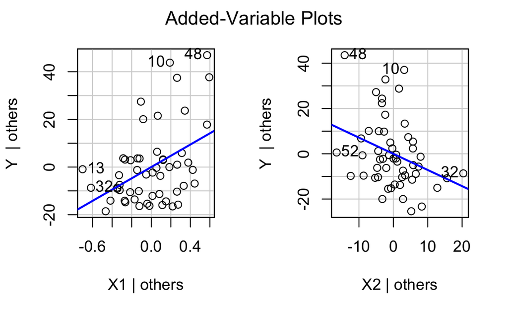

2. Checking for Violation of Assumptions on Error
4. Apply the plot function to the fit object. Make a note of any obvious violations.

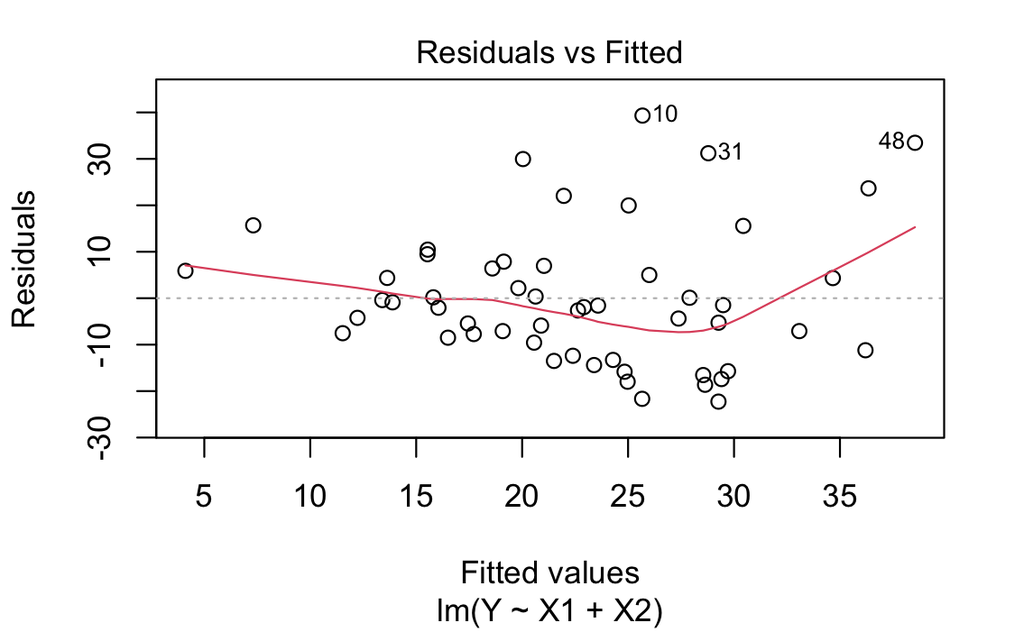

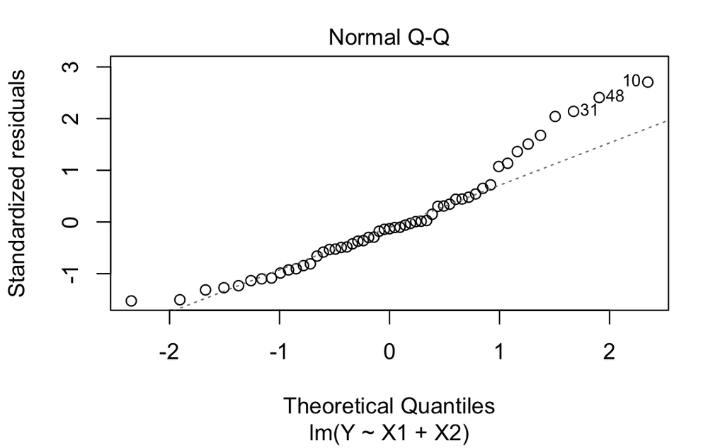

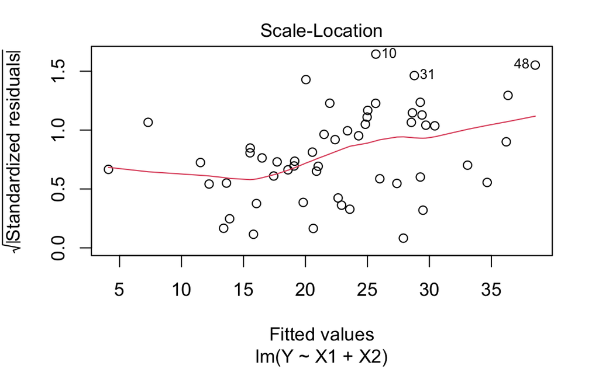

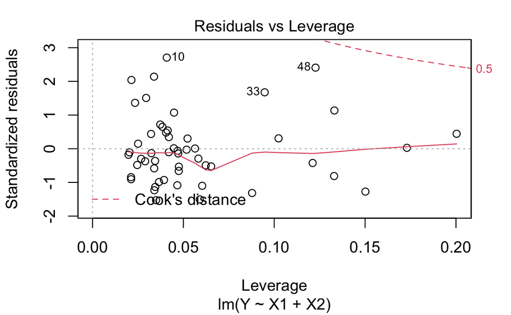

5. Plot a histogram of the studentized residuals. Does it confirm your observations in 4.?

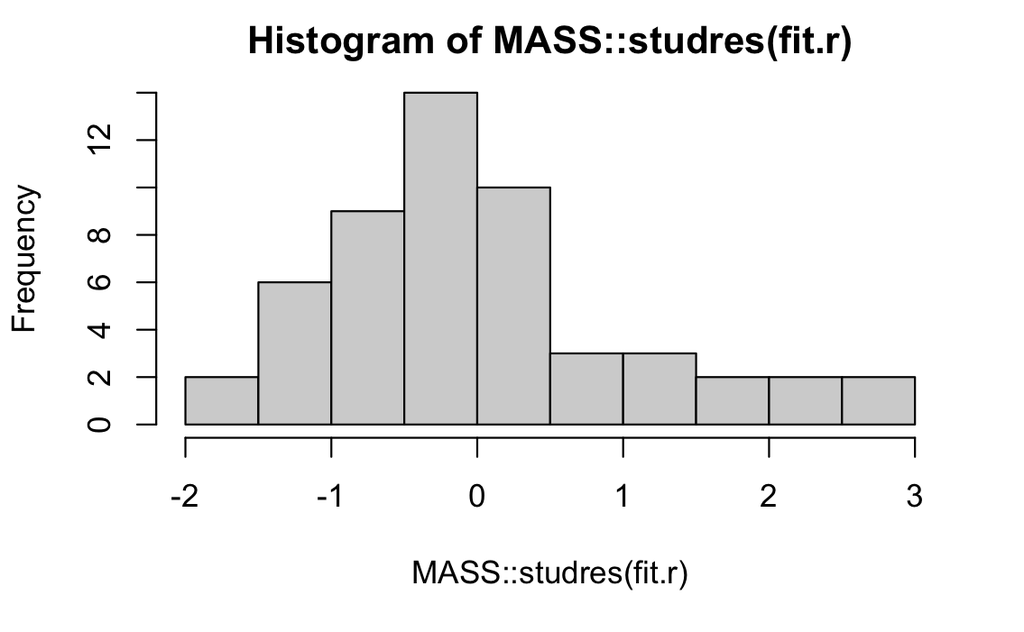

6. Does heteroscedasticity seem to be at play? Let’s run Box-Cox to diagnose. If prescribed, apply the appropriate (whole-number) transformation.

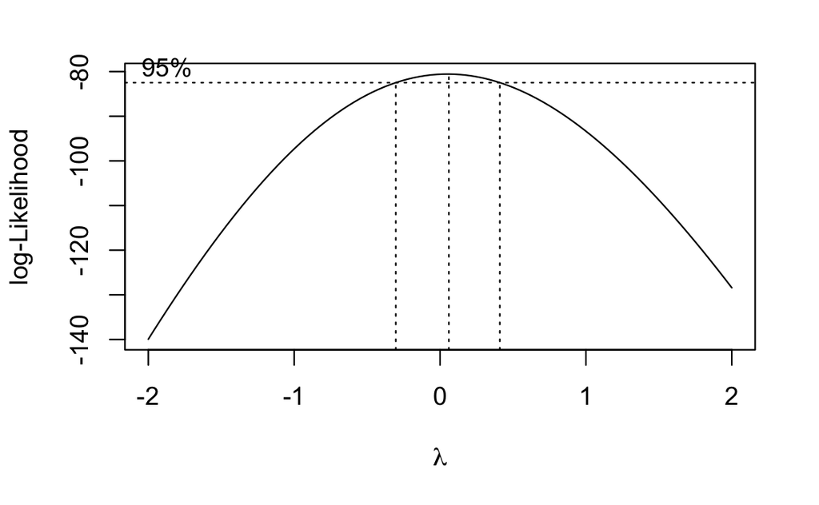

```r
MASS::boxcox(fit.r)
```

```r
fit.rl<-lm(Yl~X1+X2,data=rl)
summary(fit.rl)
```

```
Call:
lm(formula = Yl ~ X1 + X2, data = rl)

Residuals:
     Min       1Q   Median       3Q      Max
-1.58599 -0.49722  0.06988  0.48008  1.19303

Coefficients:
            Estimate Std. Error t value Pr(>|t|)
(Intercept)  3.09063    0.79728   3.876  0.00031 ***
X1           0.85789    0.29859   2.873  0.00595 **
X2          -0.02876    0.01314  -2.188  0.03335 *
---
Signif. codes:  0 ‘***’ 0.001 ‘**’ 0.01 ‘*’ 0.05 ‘.’ 0.1 ‘ ’ 1

Residual standard error: 0.647 on 50 degrees of freedom
Multiple R-squared:  0.1549,    Adjusted R-squared:  0.1211
F-statistic: 4.581 on 2 and 50 DF,  p-value: 0.0149
```

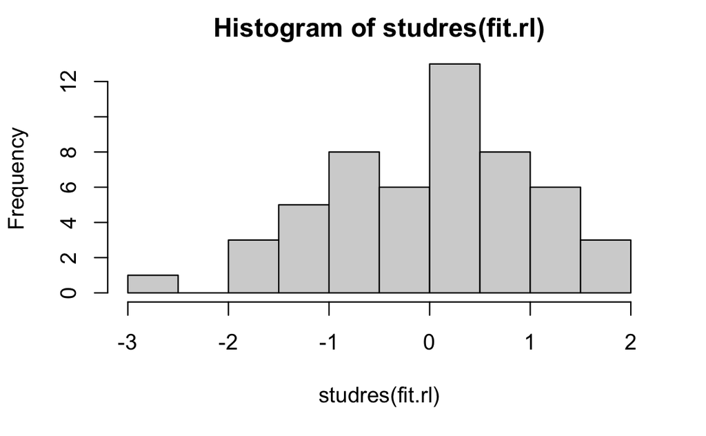

8. Let’s investigate leverage. The *hatvalues* function in the pre-loaded stats package will yield the $h_{ii}$ values for us.

```r
2*((dim(recovery)[2]-1)/dim(recovery)[1]) #Average Leverage
```

```
[1] 0.0754717
```

Now let’s make a note of the high leverage observation

```r
which(hatvalues(fit.rl)>0.0754717)
```

```
 2  7 13 28 30 32 33 41 48 52
 2  7 13 28 30 32 33 41 48 52
```

Confirming:

```r
tail(hatvalues(fit.rl))
```

```
        48         49         50         51         52
0.12271730 0.03847932 0.04196679 0.04752302 0.13294056
        53
0.02948907
```

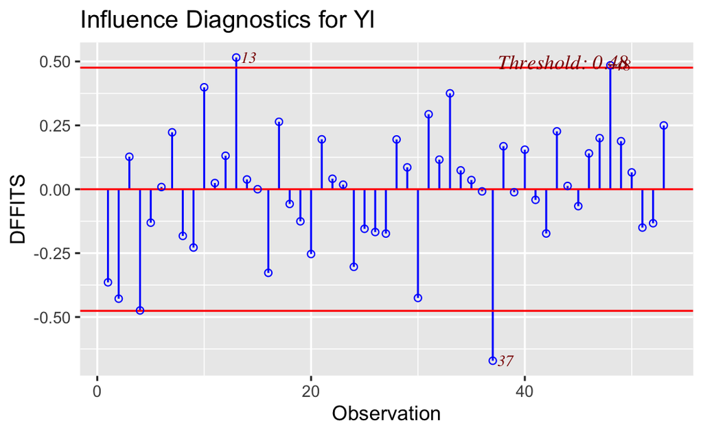

```r
ols_plot_dffits(fit.rl)
```

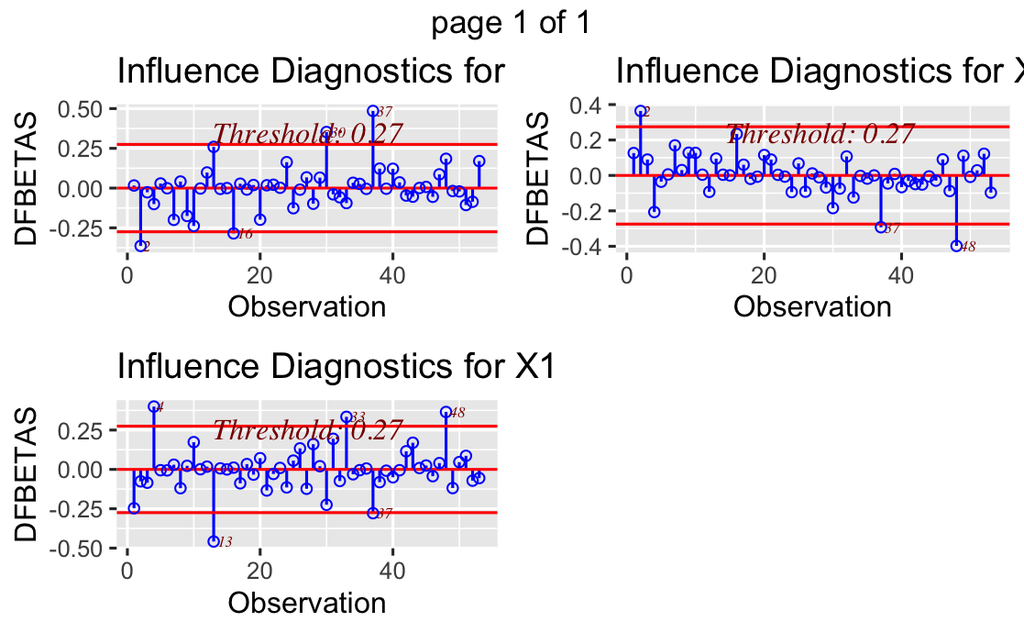

```r
ols_plot_dfbetas(fit.rl)
```

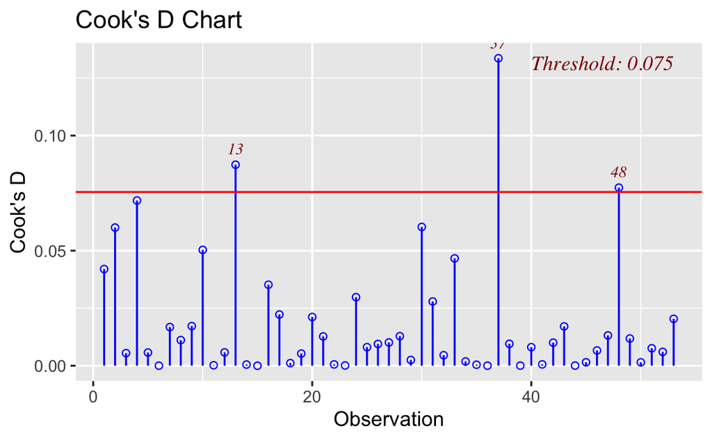

```r
ols_plot_cooksd_chart(fit.rl)
```

```r
qf(0.5,dim(recovery)[2]-1,dim(recovery)[1])
```

```
[1] 0.7022919
```

10. Conclude with observations and recommendations for how to proceed with the using this model for estimation and prediction.